# Analysis of Single-Cell RNA-seq - Session 3

Emily V Chambers

Last modified: 26 Sep 2023

# Introduction

To re-cap - we have obtained our raw counts matrices from GEO (or cellranger). We have performed QC and subset the data according to the QC plots we generated. We have normalised the data via `SCTransform` - regressing out unwanted sources of variation, and integrated across our datasets. Lastly, we have clustered the cells into separate groups based on the similarity of their expression profiles.

In the next part of the course we are going to explore the genes that show the most differences in their expression between clusters. The top genes showing the biggest change in their expression compared to the other clusters are often called *marker genes*. We can then use these marker genes to assign an *identity class* to our clusters of interest.

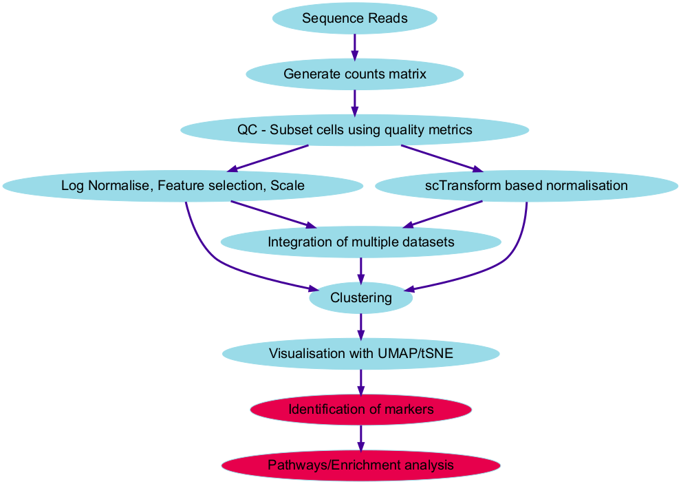

## Learning Objectives

- Find differentially expressed genes using `FindMarkers()` and `FindAllMarkers()`.
- Use the bioconductor human annotation package `org.Hs.eg.db` to add some more useful annotation to our marker genes.
- Assign cluster identity using cell type canonical marker genes
- Carry out a simple pathway analysis

Firstly, we will load up the packages we have been using so far for this part of the course.

```r
library(Seurat, quietly = T)
library(tidyverse, quietly = T)
```

And then we can load up the R objects we have used in the previous sessions.

We can simply run the name of the Seurat object (in our case `seurat`) to give us a summary of what the object contains and what calculations have been performed on it.

```r
seurat
```

```
An object of class Seurat
34549 features across 3272 samples within 3 assays
Active assay: integrated (3000 features, 3000 variable features)
 2 other assays present: RNA, SCT
 3 dimensional reductions calculated: pca, tsne, umap
```

We can recap our clusters by taking a look at the dimensionality reduction plot - `DimPlot`

```r
DimPlot(seurat, reduction = "umap")
```

[output not shown]

# Find differentially expressed genes

Our next objective is to start assigning some *biological meaning* to our data. We have some nice clusters, but no clue yet as to what cell types our clusters describe.

In Seurat we can find the top differentially-expressed genes, or *markers*, within each cluster. The function `FindAllMarkers()` handles most of the differential expression testing within the Seurat package and finds marker genes across all clusters. As a default, Seurat performs differential expression based on the non-parameteric Wilcoxon rank sum test, but other methods are available within the function.

Usually, we are wanting to find the most differentially-expressed genes in each cluster across the whole dataset. For this we use `FindAllMarkers`. We will only report the positively expressed markers with a minimum log fold change of 0.25.

```r
markers <- FindAllMarkers(seurat,
                          only.pos = TRUE,
                          min.pct = 0.25,
                          logfc.threshold = 0.25,
                          verbose = F) # keeps it quiet!
markers %>% head()
```

|  | p_val | avg_log2FC | pct.1 | pct.2 | p_val_adj | cluster | gene |
| --- | --- | --- | --- | --- | --- | --- | --- |
| RPL21 | 0.000000e+00 | 2.6475470 | 0.920 | 0.258 | 0.000000e+00 | 0 | RPL21 |
| RPS27 | 5.302008e-286 | 2.5251717 | 0.889 | 0.328 | 1.590602e-282 | 0 | RPS27 |
| RP11-701H24.9 | 6.779717e-235 | 1.1457635 | 0.363 | 0.078 | 2.033915e-231 | 0 | RP11-701H24.9 |
| RPS29 | 1.416754e-226 | 1.7852135 | 0.839 | 0.347 | 4.250262e-223 | 0 | RPS29 |
| EML5 | 3.832170e-220 | 0.8308564 | 0.340 | 0.051 | 1.149651e-216 | 0 | EML5 |
| RPS19 | 8.142875e-214 | 1.4445964 | 0.882 | 0.375 | 2.442863e-210 | 0 | RPS19 |

A bit of manipulation in `dplyr` enables us to get the top 5 DE genes in each cluster.

| gene | cluster | avg_log2FC | p_val | p_val_adj |
| --- | --- | --- | --- | --- |
| TRABD2A | 0 | 5.557770 | 9.108702e-21 | 2.732611e-17 |
| LRRN3 | 0 | 5.414920 | 2.750697e-69 | 8.252090e-66 |
| TXK | 0 | 5.163439 | 1.404019e-49 | 4.212056e-46 |
| PIK3IP1 | 0 | 5.017013 | 4.206961e-80 | 1.262088e-76 |
| MAL | 0 | 4.702415 | 7.573796e-44 | 2.272139e-40 |
| TIFA | 1 | 6.793211 | 1.410687e-121 | 4.232062e-118 |
| PCDH9 | 1 | 6.759632 | 2.650684e-158 | 7.952053e-155 |
| PDLIM1 | 1 | 6.172420 | 3.755833e-140 | 1.126750e-136 |
| CD72 | 1 | 5.891110 | 1.494792e-67 | 4.484377e-64 |
| BCL7A | 1 | 5.736877 | 6.518356e-97 | 1.955507e-93 |

[output cut: 50 more lines]

# Annotating marker genes

We may want to share our findings with collaborators or perform further bioinformatic analysis on our DE genes in clusters of interest. In this dataset, the gene level information is given as a gene name. Whilst this is useful we may want to embellish these results with some gene description information or some other gene IDs (eg Ensembl, Entrez).

The `org.Hs.eg.db` database is a genome wide annotation package for human that has many different gene mappings based on Entrez Gene identifiers. These are up-to-date databases of gene annotation that can be installed like any other bioconductor package

```r
# Dont run this if you have run already!
#install.packages("BiocManager")
#BiocManager::install("org.Hs.eg.db")

library(org.Hs.eg.db)
```

In our case we are going to use the gene symbols (rownames in our Seurat object) to extract the gene description and Entrez ID from the database.

We are going to filter the database by a key or set of keys in order to extract the information we want. Valid names for the key can be retrieved with the `keytypes` function.

```r
keytypes(org.Hs.eg.db)
```

We are going to use the keytype ‘SYMBOL’ which designates the gene names that we have in our rownames of the Seurat object.

Unfortunately, the authors of `dplyr` and `AnnotationDbi` have both decided to use the name `select` in their packages. To avoid confusion and problems from packages attempting to use the wrong tool, the following code is sometimes used:-

`AnnotationDbi::select` which tells us to use the ‘select’ function from the `AnnotationDBI` package.

```r
anno <- AnnotationDbi::select(org.Hs.eg.db,
                              keys=rownames(seurat),
                              columns=c("SYMBOL","GENENAME", "ENTREZID"),  # info we want to extract
                              keytype = "SYMBOL") # information we have

# Check it worked!
head(anno)
```

|  | SYMBOL | GENENAME | ENTREZID |
| --- | --- | --- | --- |
| 1 | LYZ | lysozyme | 4069 |
| 2 | S100A8 | S100 calcium binding protein A8 | 6279 |
| 3 | RP11-1143G9.4 | NA | NA |
| 4 | S100A9 | S100 calcium binding protein A9 | 6280 |
| 5 | HBA1 | hemoglobin subunit alpha 1 | 3039 |
| 6 | LGALS1 | galectin 1 | 3956 |

Now we can combine our annotation table to our marker genes using `dplyr` and `left_join`

| gene | cluster | avg_log2FC | p_val | p_val_adj | GENENAME | ENTREZID |
| --- | --- | --- | --- | --- | --- | --- |
| RPL21 | 0 | 2.6475470 | 0.000000e+00 | 0.000000e+00 | ribosomal protein L21 | 6144 |
| RPS27 | 0 | 2.5251717 | 5.302008e-286 | 1.590602e-282 | ribosomal protein S27 | 6232 |
| RP11-701H24.9 | 0 | 1.1457635 | 6.779717e-235 | 2.033915e-231 | NA | NA |
| RPS29 | 0 | 1.7852135 | 1.416754e-226 | 4.250262e-223 | ribosomal protein S29 | 6235 |
| EML5 | 0 | 0.8308564 | 3.832170e-220 | 1.149651e-216 | EMAP like 5 | 161436 |
| RPS19 | 0 | 1.4445964 | 8.142875e-214 | 2.442863e-210 | ribosomal protein S19 | 6223 |
| ZNF133 | 0 | 0.9837938 | 3.410762e-212 | 1.023229e-208 | zinc finger protein 133 | 7692 |
| MORC2-AS1 | 0 | 2.7652741 | 5.038148e-204 | 1.511444e-200 | MORC2 antisense RNA 1 | 150291 |
| RPL13 | 0 | 1.6435532 | 7.936629e-202 | 2.380989e-198 | ribosomal protein L13 | 6137 |
| RPL34 | 0 | 2.1609317 | 8.190218e-191 | 2.457065e-187 | ribosomal protein L34 | 6164 |

[output cut: 990 more lines]

At this point we might want to save our result into a nicely formatted file where we can look up our clusters, top DE genes and their gene descriptions.

```r
anno_markers %>% write_csv("Annotated.results.csv")
```